# The Linear Regression Model

Part III — Statistical Inference & Model Validation

Paulo Fagandini

Lisbon Accounting and Business School — Polytechnic University of Lisbon

# Statistical Inference in Regression

## Lecture Overview

**Lecture 10 — Statistical Inference & Model Validation**

- Distributions of OLS estimators under normality
- $t$-tests for individual coefficients
- Confidence intervals for $\beta_j$
- The $F$-test: overall model significance
- The ANOVA table for regression
- Point prediction and prediction intervals
- Validating the classical assumptions:
  - Linearity, normality, homoscedasticity, independence, multicollinearity

**Note**

**Reference:** Newbold Ch. 11.6–11.8, Ch. 12.4–12.6.

# Sampling Distributions of OLS Estimators

## From Estimates to Inference

We have $\hat{\beta}_j$ — point estimates. But **how uncertain** are they?

Under the classical assumptions A1–A6:

$$\hat{\beta}_j \sim N\!\left(\beta_j,\; \sigma^2_{\hat{\beta}_j}\right)$$

Since $\sigma^2$ is unknown, we replace it with $s^2 = \text{SSR}/(n-k-1)$:

$$T_j = \frac{\hat{\beta}_j - \beta_j}{s_{\hat{\beta}_j}} \sim t_{n-k-1}$$

where $s_{\hat{\beta}_j}$ is the **standard error** of $\hat{\beta}_j$ (reported by R in the `Std. Error` column).

**Note**

In SLR ($k=1$): $s_{\hat{\beta}_1} = \dfrac{s}{\sqrt{S_{XX}}}$, where $s = \sqrt{\text{SSR}/(n-2)}$.

# $t$-Tests for Individual Coefficients

## The Individual Significance Test

**Question:** Is the variable $X_j$ statistically significant — i.e. does it contribute to explaining $Y$?

**Hypotheses:**

$$H_0: \beta_j = 0 \quad \text{vs} \quad H_1: \beta_j \neq 0$$

**Test statistic:**

$$t_j = \frac{\hat{\beta}_j}{s_{\hat{\beta}_j}} \;\sim\; t_{n-k-1} \quad \text{under } H_0$$

**Decision rule** at significance level $\alpha$:

| Approach | Rule |
| --- | --- |
| Critical value | Reject $H_0$ if $\|t_j\| > t_{n-k-1,\,\alpha/2}$ |
| $p$-value | Reject $H_0$ if $p\text{-value} < \alpha$ |

## Reading the R Output

```r
summary(mlr_model)
```

```
Call:
lm(formula = profit2 ~ revenue2 + employees)

Residuals:
     Min       1Q   Median       3Q      Max
-21.8947  -9.0708  -0.1219   6.0029  25.3186

Coefficients:
            Estimate Std. Error t value Pr(>|t|)
(Intercept) 21.46125    9.51476   2.256   0.0324 *
revenue2     0.12902    0.02048   6.299 9.66e-07 ***
employees    0.61262    0.11789   5.196 1.80e-05 ***
---
Signif. codes:  0 '***' 0.001 '**' 0.01 '*' 0.05 '.' 0.1 ' ' 1

Residual standard error: 12.43 on 27 degrees of freedom
Multiple R-squared:  0.6543,    Adjusted R-squared:  0.6287
F-statistic: 25.55 on 2 and 27 DF,  p-value: 5.923e-07
```

## Interpreting the $t$-test Output

From the `Coefficients` table in `summary()`:

| Column | Meaning |
| --- | --- |
| `Estimate` | $\hat{\beta}_j$ — the OLS point estimate |
| `Std. Error` | $s_{\hat{\beta}_j}$ — standard error of the estimate |
| `t value` | $t_j = \hat{\beta}_j / s_{\hat{\beta}_j}$ — the test statistic |
| `Pr(>\|t\|)` | Two-sided $p$-value: probability of observing $\|t_j\|$ this large **if $H_0$ were true** |
| Significance codes | `***` $p<0.001$, `**` $p<0.01$, `*` $p<0.05$, `.` $p<0.1$ |

**Important**

If `Pr(>|t|)` $< \alpha$ (e.g. 0.05): **reject $H_0$** — the variable is statistically significant at level $\alpha$.

If not: we **fail to reject $H_0$** — the variable may not be contributing to the model after controlling for the others (principle of parsimony: consider removing it).

## One-Sided Tests

Sometimes theory suggests a **directional** hypothesis:

$$H_0: \beta_j = 0 \quad \text{vs} \quad H_1: \beta_j > 0 \quad \text{(or } H_1: \beta_j < 0\text{)}$$

The test statistic is the same $t_j = \hat{\beta}_j / s_{\hat{\beta}_j}$.

For $H_1: \beta_j > 0$: reject $H_0$ if $t_j > t_{n-k-1,\,\alpha}$

For $H_1: \beta_j < 0$: reject $H_0$ if $t_j < -t_{n-k-1,\,\alpha}$

**Note**

The $p$-value from R is always **two-sided**. For a one-sided test, divide it by 2 — but only when the sign of $\hat{\beta}_j$ is consistent with $H_1$.

# Confidence Intervals for $\beta_j$

## Construction

A $(1-\alpha) \times 100\%$ confidence interval for $\beta_j$:

$$\hat{\beta}_j \;\pm\; t_{n-k-1,\,\alpha/2} \;\cdot\; s_{\hat{\beta}_j}$$

**Important**

**Interpretation:** If we repeated the sampling procedure many times, $(1-\alpha)\times 100\%$ of the intervals constructed this way would contain the true $\beta_j$.

The interval gives a range of **plausible values** for $\beta_j$ given the data.

**Link to hypothesis testing:** if $0$ is **not** in the $95\%$ confidence interval for $\beta_j$, then $H_0: \beta_j = 0$ is rejected at $\alpha = 5\%$.

## Confidence Intervals in R

```r
confint(mlr_model, level = 0.95)
```

```
                 2.5 %     97.5 %
(Intercept) 1.93857748 40.9839143
revenue2    0.08699515  0.1710521
employees   0.37072535  0.8545246
```

**Interpretation:**

- The 95% CI for $\beta_{\text{revenue}}$ is approximately [0.087, 0.171].
- Since 0 is **not** in this interval, we reject $H_0: \beta_{\text{revenue}} = 0$ at 5% — revenue has a statistically significant positive effect on profit.

# The $F$-Test: Overall Significance

## Motivation

The $t$-tests assess **individual** regressors. But sometimes we want to ask:

> *Does the model as a whole explain a significant amount of variation in $Y$?*

This is the **overall significance test**:

$$H_0: \beta_1 = \beta_2 = \cdots = \beta_k = 0$$
$$H_1: \text{at least one } \beta_j \neq 0$$

**Important**

Under $H_0$, none of the regressors help explain $Y$ — the model is no better than simply predicting $\bar{Y}$ for everyone.

## The $F$-Statistic

$$F = \frac{\text{SSE}/k}{\text{SSR}/(n-k-1)} = \frac{\text{Explained MS}}{\text{Residual MS}} \;\sim\; F_{k,\, n-k-1} \quad \text{under } H_0$$

**The ANOVA table for regression:**

| Source | SS | df | MS | $F$ |
| --- | --- | --- | --- | --- |
| Regression (Explained) | SSE | $k$ | SSE/$k$ | MSE/MSR |
| Residual | SSR | $n-k-1$ | SSR/$(n-k-1)$ |  |
| **Total** | **SST** | $n-1$ |  |  |

**Decision:** Reject $H_0$ if $F > F_{k,\,n-k-1,\,\alpha}$ or if $p\text{-value} < \alpha$.

## $F$-Test in R

The $F$-statistic and its $p$-value appear at the **bottom** of `summary()`:

```r
summary(mlr_model)
```

```
Call:
lm(formula = profit2 ~ revenue2 + employees)

Residuals:
     Min       1Q   Median       3Q      Max
-21.8947  -9.0708  -0.1219   6.0029  25.3186

Coefficients:
            Estimate Std. Error t value Pr(>|t|)
(Intercept) 21.46125    9.51476   2.256   0.0324 *
revenue2     0.12902    0.02048   6.299 9.66e-07 ***
employees    0.61262    0.11789   5.196 1.80e-05 ***
---
Signif. codes:  0 '***' 0.001 '**' 0.01 '*' 0.05 '.' 0.1 ' ' 1

Residual standard error: 12.43 on 27 degrees of freedom
Multiple R-squared:  0.6543,    Adjusted R-squared:  0.6287
F-statistic: 25.55 on 2 and 27 DF,  p-value: 5.923e-07
```

The line `F-statistic: ... on k and n-k-1 DF, p-value: ...` gives the overall test.

## Relationship Between $F$ and $R^2$

In MLR, the $F$-statistic can be written as:

$$F = \frac{R^2/k}{(1-R^2)/(n-k-1)}$$

This makes clear that:

- A high $R^2$ tends to produce a large $F$ (and small $p$-value)
- But a significant $F$ does **not** mean all individual coefficients are significant
- And a significant $t_j$ does **not** imply overall model significance

**Note**

In SLR ($k = 1$): $F = t^2$ — the $F$-test is equivalent to the two-sided $t$-test on the single slope.

# Prediction

## Point Prediction

Given new values $X_1 = x_1^*, \ldots, X_k = x_k^*$, the **point prediction** is:

$$\hat{Y}^* = \hat{\beta}_0 + \hat{\beta}_1 x_1^* + \cdots + \hat{\beta}_k x_k^*$$

```r
# Predict profit for revenue = 300, employees = 40
new_obs <- data.frame(revenue2 = 300, employees = 40)
predict(mlr_model, newdata = new_obs)
```

```
       1
84.67332
```

**Important**

**Extrapolation warning:** predictions are only reliable within the range of the observed data. Predicting far outside the sample range (e.g. revenue = 5000 when the data only covers 100–500) is unreliable.

## Prediction Intervals

A **prediction interval** accounts for two sources of uncertainty:

1. Uncertainty about the true mean $E[Y^*]$ (same as a confidence interval for the mean)
2. Uncertainty about the **individual** outcome $Y^*$ around that mean

$$\hat{Y}^* \;\pm\; t_{n-k-1,\,\alpha/2} \;\cdot\; s \cdot \sqrt{1 + \mathbf{x}^{*\prime}(\mathbf{X}'\mathbf{X})^{-1}\mathbf{x}^*}$$

In R:

```r
predict(mlr_model, newdata = new_obs,
        interval = "prediction", level = 0.95)
```

```
       fit      lwr      upr
1 84.67332 58.73202 110.6146
```

The prediction interval is **always wider** than the confidence interval for the mean — it must additionally account for individual variation.

# Validating the Classical Assumptions

## Why Validation Matters

Our inference (t-tests, F-test, confidence intervals) is only valid if the classical assumptions hold.

**If they fail:**

- **A2 violated** (non-zero mean error, omitted variables): OLS is biased
- **A3 violated** (heteroscedasticity): OLS standard errors are wrong → invalid $t$ and $F$ tests
- **A4 violated** (autocorrelation): same problem as heteroscedasticity
- **A6 violated** (non-normality): $t$ and $F$ approximations may fail in small samples
- **Multicollinearity** (not a classical assumption violation): inflated standard errors, unstable estimates

The tool for checking assumptions: **residual analysis**.

## The Four Key Diagnostic Plots

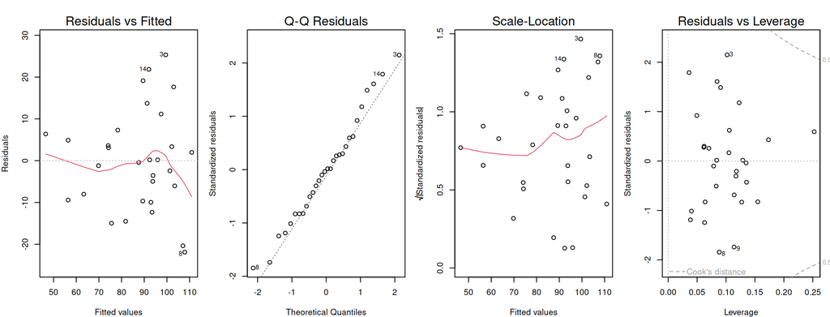

```r
par(mfrow = c(1, 4), mar = c(4, 4, 3, 1))
plot(mlr_model)
```

## Residuals vs. Fitted: Checking Linearity and Homoscedasticity

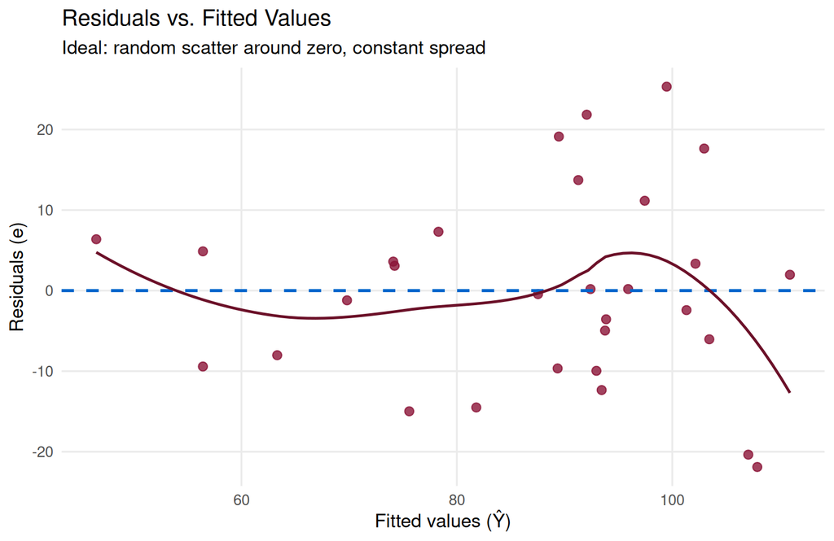

**What to look for:**

- **Random scatter around zero** → linearity OK
- **Constant vertical spread** → homoscedasticity OK
- **Funnel or fan shape** → heteroscedasticity (problem)
- **Curved pattern** → non-linearity (problem)

## Normality of Residuals: Q–Q Plot

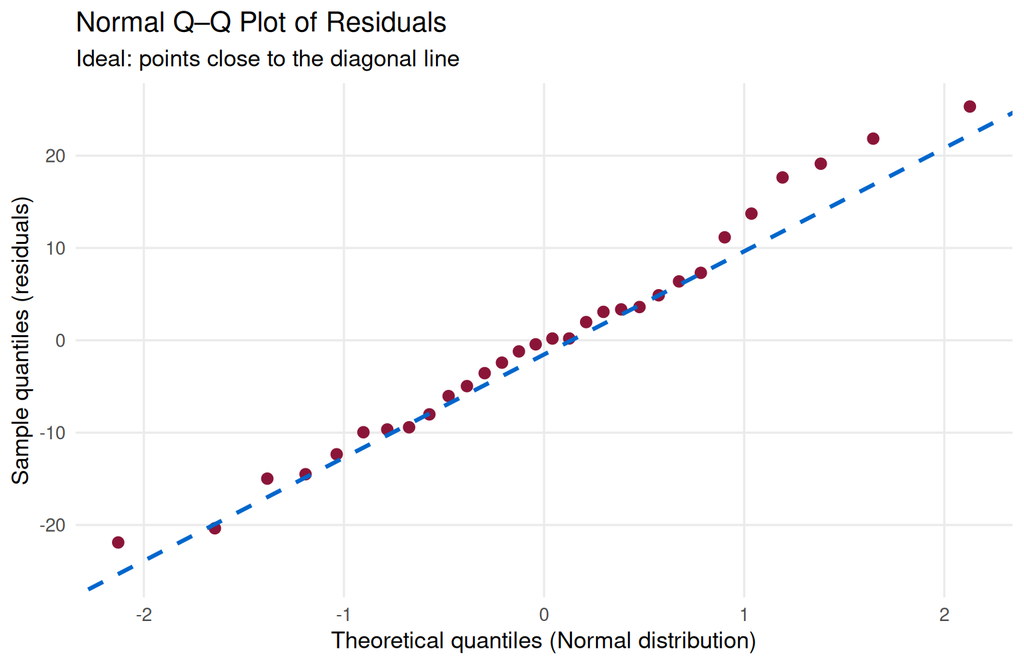

**What to look for:**

- **Points near the diagonal** → normality approximately satisfied
- **S-shaped curve** → heavy tails (non-normal)
- **Systematic departure** → consider transformations of $Y$

## Detecting Heteroscedasticity

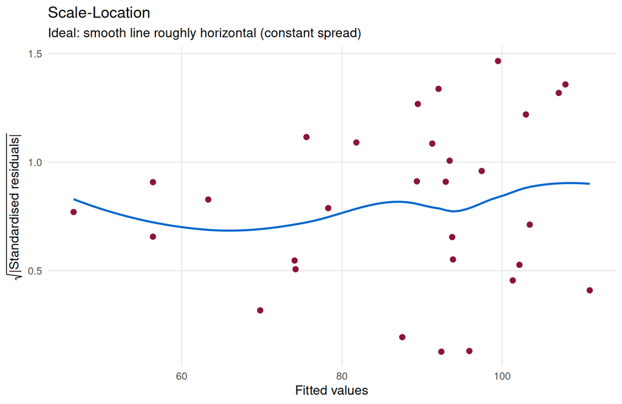

**Problem signs:**

- Rising line → variance increases with $\hat{Y}$ (funnel-right)
- Falling line → variance decreases with $\hat{Y}$ (funnel-left)

**Formal test:** White’s test (tests whether residual variance depends on any regressor or its square).

**Practical fix:** Use robust (heteroscedasticity-consistent) standard errors or transform $Y$ (e.g. $\log Y$).

## The Classical Assumptions: Summary Table

| Assumption | How to check | Symptom if violated | Consequence |
| --- | --- | --- | --- |
| **A1** Linearity | Scatter plot, residuals vs. fitted | Curved pattern | Biased estimates |
| **A2** Zero mean | Residuals vs. fitted | Systematic non-zero residuals | Biased $\hat{\beta}_0$ |
| **A3** Homoscedasticity | Scale-location plot, White’s test | Funnel shape | Invalid SEs & tests |
| **A4** No autocorrelation | Durbin-Watson statistic, residuals vs. order | Pattern in residuals | Invalid SEs & tests |
| **A6** Normality | Q–Q plot, Shapiro-Wilk test | S-curve in Q–Q | Invalid small-sample tests |
| — | Multicollinearity: VIF | High pairwise $r$, VIF $> 5$ | Inflated SEs, unstable $\hat{\beta}_j$ |

## Autocorrelation: The Durbin–Watson Test

Relevant mainly for **time series** data. Tests $H_0$: no autocorrelation vs. $H_1$: positive autocorrelation.

$$DW = \frac{\sum_{i=2}^{n}(e_i - e_{i-1})^2}{\sum_{i=1}^{n} e_i^2}$$

**Rule of thumb:** $DW \approx 2$ → no autocorrelation; $DW < 1.5$ → concern.

```r
# install.packages("lmtest") if needed
library(lmtest)
dwtest(mlr_model)
```

```
    Durbin-Watson test

data:  mlr_model
DW = 1.6312, p-value = 0.1308
alternative hypothesis: true autocorrelation is greater than 0
```

## Multicollinearity and VIF

**Multicollinearity:** two or more regressors are highly correlated with each other.

**Consequence:** OLS is still unbiased and BLUE, but standard errors are inflated → $t$-statistics are small → we may fail to detect significant effects.

The **Variance Inflation Factor (VIF)** for regressor $X_j$:

$$\text{VIF}_j = \frac{1}{1 - R_j^2}$$

where $R_j^2$ is the $R^2$ from regressing $X_j$ on all other regressors.

**Note**

**Rule of thumb:** VIF $< 5$ is acceptable; VIF $> 10$ is a serious problem.

## VIF in R

```r
# install.packages("car") if needed
library(car)
vif(mlr_model)
```

```
 revenue2 employees
 1.110802  1.110802
```

Both VIF values are close to 1 → no multicollinearity problem in our example. This is expected since `revenue2` and `employees` were generated independently.

## Putting It All Together: Model Validation Workflow

1. **Fit the model** with `lm()` and check `summary()` for coefficient signs, magnitudes and significance.
2. **Plot residuals vs. fitted** — check for linearity and homoscedasticity.
3. **Inspect the Q–Q plot** — check for normality of residuals.
4. **Run Durbin-Watson** (if data may have time ordering) — check for autocorrelation.
5. **Compute VIF** (if $k \geq 2$) — check for multicollinearity.
6. If violations are found: consider **transformations** (log $Y$, log $X$), **robust standard errors**, or **model re-specification** (add/remove variables).

**Important**

Validation is not a single pass — it is an **iterative dialogue** between the model and the data.

# Complete R Workflow

## End-to-End: From Data to Validated Model

```r
# 1. Fit the model
model <- lm(Y ~ X1 + X2, data = mydata)

# 2. Inspect results
summary(model)
confint(model, level = 0.95)

# 3. Residual diagnostics
par(mfrow = c(2, 2))
plot(model)

# 4. Autocorrelation (if needed)
library(lmtest)
dwtest(model)

# 5. Multicollinearity (if k >= 2)
library(car)
vif(model)

# 6. Predict for new data
predict(model,
        newdata = data.frame(X1 = x1_new, X2 = x2_new),
        interval = "prediction",
        level = 0.95)
```

## Reading a Regression Table

A typical regression output table (as seen in R or SPSS):

|  | Estimate | Std. Error | $t$ value | $\Pr(>\|t\|)$ |
| --- | --- | --- | --- | --- |
| (Intercept) | $\hat{\beta}_0$ | $s_{\hat{\beta}_0}$ | $t_0$ | $p_0$ |
| $X_1$ | $\hat{\beta}_1$ | $s_{\hat{\beta}_1}$ | $t_1$ | $p_1$ |
| $X_2$ | $\hat{\beta}_2$ | $s_{\hat{\beta}_2}$ | $t_2$ | $p_2$ |

| Metric | What it tells you |
| --- | --- |
| Residual std. error ($s$) | Typical size of residuals; in the same units as $Y$ |
| $R^2$ | Proportion of variance in $Y$ explained |
| Adjusted $R^2$ | $R^2$ penalised for number of regressors |
| $F$-statistic | Overall significance of the model |

# Course Summary: Linear Regression

## The Linear Regression Journey (3 Lectures)

| Lecture | Topic | Key Concepts |
| --- | --- | --- |
| **8** | Introduction & OLS | Model specification, Gauss–Markov assumptions, OLS formulas, coefficient interpretation |
| **9** | Fit & MLR | $R^2$, $\bar{R}^2$, Gauss–Markov theorem, Omitted Variable Bias, MLR *ceteris paribus* interpretation |
| **10** | Inference & Validation | $t$-tests, $F$-test, CIs, prediction intervals, residual diagnostics, VIF |

**The core message:**

> OLS gives us the best linear unbiased estimates — but only if the classical assumptions hold. Always validate your model before drawing conclusions.

## Key Formulas at a Glance

|  | Formula |
| --- | --- |
| OLS slope | $\hat{\beta}_1 = S_{XY}/S_{XX}$ |
| OLS intercept | $\hat{\beta}_0 = \bar{Y} - \hat{\beta}_1\bar{X}$ |
| Error variance | $s^2 = \text{SSR}/(n-k-1)$ |
| $R^2$ | $1 - \text{SSR}/\text{SST}$ |
| Adjusted $R^2$ | $1 - (1-R^2)(n-1)/(n-k-1)$ |
| $t$-statistic | $t_j = \hat{\beta}_j / s_{\hat{\beta}_j}$ |
| CI for $\beta_j$ | $\hat{\beta}_j \pm t_{n-k-1,\alpha/2} \cdot s_{\hat{\beta}_j}$ |
| $F$-statistic | $(\text{SSE}/k)\,/\,(\text{SSR}/(n-k-1))$ |